# LOESS & GAM (Notes)

Stat 253

Author

Your Name

# Nonparametric v. Parametric Models

## Notes

**CONTEXT**

- **world = supervised learning**  
  We want to model some output variable $y$ using a set of potential predictors ($x_1, x_2, ..., x_p$).
- **task = regression**  
  $y$ is quantitative
- **(nonparametric) algorithm**

**GOAL**

Our usual *parametric* models (eg: linear regression) are too rigid to represent the relationship between $y$ and our predictors $x$. Thus we need more *flexible* **nonparametric models**.

## Discussion

**EXAMPLE 1: KNN (Review)**

In the previous activity, we modeled college `Grad.Rate` versus `Expend`, `Enroll`, and `Private` using data on 775 schools.

1. We chose the KNN with K = 33 because it *minimized* the CV MAE, i.e. the errors when predicting grad rate for schools *outside* our sample. We don’t typically worry about a more *parsimonious* KNN, i.e. a model that has slightly higher prediction errors but is easier to interpret, apply, etc. Why?
2. What *assumptions* did the KNN model make about the relationship of `Grad.Rate` with `Expend`, `Enroll`, and `Private`? Is this a pro or con?
3. What did the KNN model tell us about the *relationship* of `Grad.Rate` with `Expend`, `Enroll`, and `Private`? For example, did it give you a sense of whether grad rates are higher at private or public institutions? At institutions with higher or lower enrollments? Is this a pro or con?

**EXAMPLE 2: nonparametric KNN vs parametric least squares and LASSO**

- When *should* we use a nonparametric algorithm like KNN?
- When *shouldn’t* we?

# LOESS

## Notes

**Local Regression or Locally Estimated Scatterplot Smoothing (LOESS)**

**Goal:**  
Build a **flexible** regression model of $y$ by *one* quantitative predictor $x$,

$$y = f(x) + \varepsilon$$

**Idea:**

Fit regression models in small localized regions, where nearby data have greater influence than far data.

**Algorithm:**

Define the *span*, aka bandwidth, tuning parameter $h$ where $0 \le h \le 1$. Take the following steps to estimate $f(x)$ at each possible predictor value $x$:

1. Identify a neighborhood consisting of the $100∗h$% of cases that are closest to $x$.
2. Putting more weight on the neighbors closest to $x$ (ie. allowing them to have more influence), fit a linear model in this neighborhood. 3. Use the local linear model to estimate f(x).

**In pictures:**

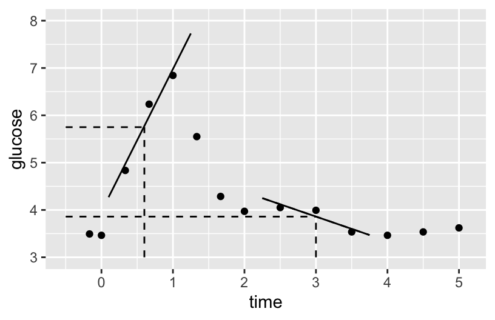

## Discussion

**EXAMPLE 3: LOESS in R**

We can plot LOESS models using `geom_smooth()`. Play around with the `span` parameter below.

- What happens as we increase the span from roughly 0 to roughly 1?
- What is one “pro” of this nonparametric algorithm, relative to KNN?
- What questions do you have about this algorithm?

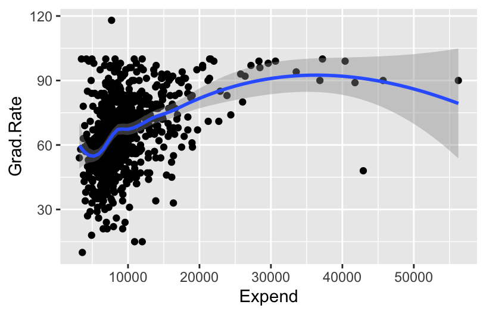

```r
library(tidyverse)
library(ISLR)
data(College)

ggplot(College, aes(x = Expend, y = Grad.Rate)) +
  geom_point() +
  geom_smooth(method = "loess", span = 0.5)
```

**EXAMPLE 4: LOESS & the Bias-Variance Tradeoff**

Use the below **shiny app** to explore the impact of the *span tuning parameter h* on the LOESS performance across different datasets. Continue to click the Go! button to get different datasets.

1. *high bias* but *low variance*
   - h near 0
   - h somewhere in the middle
   - h near 1
2. *low bias* but *high variance*
   - h near 0
   - h somewhere in the middle
   - h near 1
3. *moderate bias* and *low variance*
   - h near 0
   - h somewhere in the middle
   - h near 1

```r
# Load packages & data
library(shiny)
library(tidyverse)

# Define a LOESS plotting function
plot_loess <- function(h, plot_data){
  ggplot(plot_data, aes(x = x, y = y)) +
    geom_point() +
    geom_smooth(span = h, se = FALSE) +
    labs(title = paste("h = ", h)) +
    lims(y = c(-5,12))
}

# BUILD THE SERVER
# These are instructions for building the app - what plot to make, what quantities to calculate, etc
server_LOESS <- function(input, output) {
  new_data <- eventReactive(input$do, {
    x <- c(runif(25, -6, -2.5), runif(50, -3, 3), runif(25, 2.5, 6))
    y <- 9 - x^2 + rnorm(100, sd = 0.75)
    y[c(1:25, 76:100)] <- rnorm(50, sd = 0.75)
    data.frame(x, y)
  })
  output$loesspic <- renderPlot({
    plot_loess(h = input$hTune, plot_data = new_data())
  })
}


# BUILD THE USER INTERFACE (UI)
# The UI controls the layout, appearance, and widgets (eg: slide bars).
ui_LOESS <- fluidPage(
  sidebarLayout(
    sidebarPanel(
      h4("Sample 100 observations:"),
      actionButton("do", "Go!"),
      h4("Tune the LOESS:"),
      sliderInput("hTune", "h", min = 0.05, max = 1, value = 0.05)
    ),
    mainPanel(
      h4("LOESS plot:"),
      plotOutput("loesspic")
    )
  )
)


# RUN THE SHINY APP!
shinyApp(ui = ui_LOESS, server = server_LOESS)
```

# GAMs

## Notes

**Generalized Additive Models (GAM)**

GAMs are **nonparametric** nonlinear models that can handle more than one predictor. They incorporate each predictor $x_i$ through some nonparametric, smooth function $f_i()$:

$$y = \beta_0 + f_1(x_1) + f_2(x_2) + \cdots + f_p(x_p) + \varepsilon$$

**Big ideas**

NOTE: More optional details are included in the “Deeper learning” section.

**TECHNICAL NOTE**

In `tidymodels()`:

- The GAM f(x) components are estimated using **smoothing splines**, a nonparametric smoothing technique that’s more nuanced than LOESS.
- Smoothing splines depend upon a $\lambda$ *penalty* tuning parameter (labeled `adjust_deg_free` in `tidymodels`). As in the LASSO:
  - the bigger the $\lambda$, the more simple / less wiggly the estimate of f(x)
  - if $\lambda$ is big enough, we might even kick a predictor out of the model

Optional details are in the “Deeper Learning” section.

## Discussion

**EXAMPLE 5: GAM**

Interpret the wage analysis in Chapter 7 of [ISLR](https://hastie.su.domains/ISLR2/ISLRv2_website.pdf).

wage = $\beta_0$ + f(year) + f(age) + f(education) + $\varepsilon$

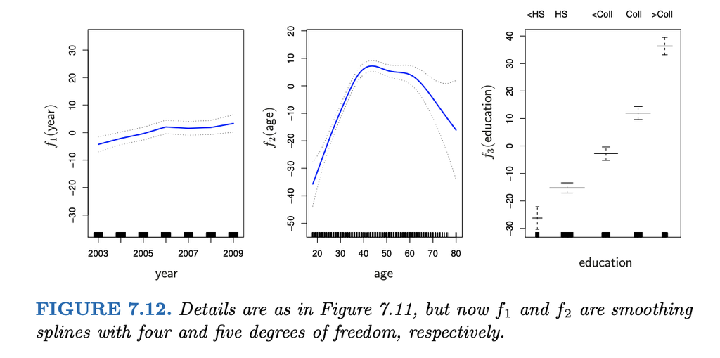

# Other Flexible Models

**NOTE**

KNN, LOESS, and GAM aren’t the only algorithms for building more flexible models! Chapter 7 of the book also discusses:

- piecewise polynomials
- regression splines
- smoothing splines

# Exercises

**Goals**

- Implement and explore GAM in R.
- Explore how this algorithm compares to others, hence how it fits into our broader ML workflow.

**Context**

Using the `College` data in the `ISLR` package, we’ll build a predictive model of `Grad.Rate` by 6 predictors:

`Private`, `PhD` (percent of faculty with PhDs), `Room.Board`, `Personal` (estimated personal spending), `Outstate` (out-of-state tuition), `perc.alumni` (percent of alumni who donate)

```r
# Load packages
library(tidymodels)
library(tidyverse)
library(ISLR)

# Load data
data(College)

# Wrangle the data
college_sub <- College %>%
  filter(Grad.Rate <= 100) %>%
  filter((Grad.Rate > 50 | Expend < 40000)) %>%
  select(Grad.Rate, Private, PhD, Room.Board, Personal, Outstate, perc.alumni)
```

## Part 1: Building a GAM

Let’s build a GAM of `Grad.Rate` by all 6 predictors in `college_sub`:

$$\text{Grad.Rate} = \beta_0 + \beta_1\text{PrivateYes} + f_2(\text{PhD}) + \cdots + f_{6}(\text{perc.alumni}) + \varepsilon$$

You’re given all code here. Be sure to scan and reflect upon what’s happening.

**STEP 1: Specifying the GAM**

Specify the GAM algorithm. Ask yourself the following about each line:

- How, if at all, does this differ from the code for LASSO or KNN?
- What’s the point?

```r
gam_spec <- gen_additive_mod() %>%
  set_mode("regression") %>%
  set_engine(engine = "mgcv") %>%
  set_args(adjust_deg_free = tune(), select_features = TRUE)
```

**STEP 2: variable recipe**

NOTE: each $f_j(x_j)$ uses only a single predictor $x_j$, we don’t have to worry about predictor scales or pre-processing.

```r
variable_recipe <- recipe(Grad.Rate ~ ., data = college_sub)
```

**STEP 3: workflow specification**

Set up our GAM workflow. Check out the `formula` required by `add_model`:

- How did we include the *categorical* `Private` predictor?
- How did we include the other *quantitative* predictors?
- Thinking back to the technical note about the GAM in `tidymodels`, what do you think `s()` stands for?

```r
gam_workflow <- workflow() %>%
  add_recipe(variable_recipe) %>%
  add_model(gam_spec,
            formula = Grad.Rate ~ Private + s(PhD) + s(Room.Board) + s(Personal) + s(Outstate) + s(perc.alumni))
```

**STEP 4: estimate multiple GAMs**

Finally, estimate the GAM using a range of values for `adjust_deg_free()`, the $\lambda$ tuning parameter.

- Recall: the bigger the parameter, the greater the *penalty* for overfit, wiggly behavior.
- We’ll try **10** possible values for the penalty parameter, ranging from **0.25 to 4**, and evaluate each model with respect to its **10-fold** CV MAE.
- Running this code will take some time (typically under 30 seconds). The more predictors we have, the longer it takes!

```r
set.seed(253)
gam_models <- gam_workflow %>%
  tune_grid(
    grid = grid_regular(adjust_deg_free(range = c(0.25, 4)),
                        levels = 10),
    resamples = vfold_cv(college_sub, v = 10),
    metrics = metric_set(mae)
  )
```

## Part 2: Identify and apply a “final” GAM

### Exercise 1: Computational time

We only ran 10 different GAMs of `Grad.Rate` by our 6 predictors above. What is it about this algorithm that makes it take so long?

NOTE: In general, the GAM is not great when we have lots of predictors. In that case, we might use a poorly fit LASSO to help pick predictors, and then use GAM with these predictors for our final model and predictions.

### Exercise 2: Identify the best GAM

Using the same concepts (and code!) as when we tuned the LASSO and KNN algorithms:

```r
# Use a plot to compare the predictive performance of our 10 GAM models


# Pick the best value for the penalty tuning parameter
# Name this `best_penalty`


# Fit a final GAM using `best_penalty`
# Name this `final_gam`
```

### Exercise 3: Explore the final GAM

Plot the smoothing functions for each predictor in our model. NOTES:

- The `$` notation accesses nested objects (`fit` within `fit` within `fit` within `final_gam`).
- You can remove `eval = FALSE` now that you’ve defined `final_gam` above.

```r
final_gam$fit$fit$fit %>%
  plot(all.terms = TRUE, pages = 1)
```

1. Is there anything in these plots that justifies our use of the GAM instead of least squares?
2. Pick 1 or 2 of these plots and interpret your findings.

### Exercise 4: Pick an algorithm

Our overall goal is to build a predictive model of `Grad.Rate` ($y$) by 6 predictors:

$$y = f(x_1,x_2,...,x_{6}) + \varepsilon$$

| method | type | assumption about $f(x_1,x_2,...,x_{6})$ | CV MAE |
| --- | --- | --- | --- |
| least squares | parametric | $\beta_0 + \beta_1x_1 + \cdots + \beta_{6} x_{6}$ | 10.2 |
| KNN w/ $K = 33$ | nonparametric | average $y$ among neighbors | 10.2 |
| GAM w/ penalty = 1.5 | nonparametric | $\beta_0 + f_1(x_1) + \cdots + f_{6}(x_{6})$ | 10.2 |

## Part 3: Reflection

In these final exercises, you’ll reflect upon some algorithms we’ve learned thus far. This might feel bumpy if you haven’t reviewed the material recently, so be kind to yourself!

Some of these exercises are similar to those on Homework 4. Thus solutions are not provided. The following directions are important to deepening your learning and growth.

- Typing the questions into ChatGPT does not require any reflection: **You may NOT use ChatGPT or other online resources for these questions or on Homework 4.**
- Locating is not learning: Challenge yourself to write out concepts in *your own words*. Do not rely on definitions in the activities, videos, or elsewhere.

### Exercise 5: Interpretability & flexibility

When picking between different model building algorithms, there are several considerations, including *flexibility* and *interpretability*. Consider the following graphic from ISLR:

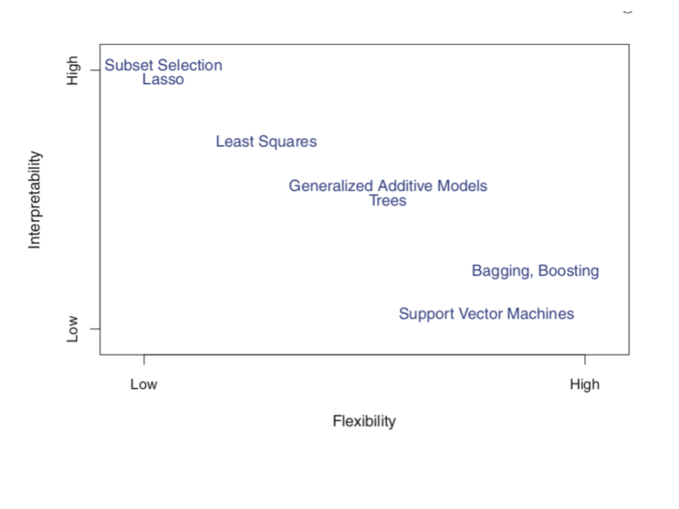

1. Convince yourself that the placement of Subset Selection (e.g. backward stepwise), LASSO, Least Squares, and GAM make sense. (We’ll address the other algorithms later this semester.)
2. Where would you place KNN on this graphic?

### Exercise 6: Differences and similarities

For each pair of algorithms below: try to identify a key *similarity*, a key *difference*, and any scenario in which they’re “equivalent”.

1. KNN vs LOESS
2. LOESS vs GAM
3. GAM vs least squares
4. least squares vs LASSO

### Exercise 7: Pros & cons (there’s a similar question on HW 4)

Summarize at least 1 pro and 1 con about each model building algorithm. You cannot use the same pro or con more than once!

1. least squares
2. LASSO
3. KNN
4. GAM

### Exercise 8: Lingo (there’s a similar question on HW 4)

In your own words, describe what each of these “everyday” words means in the context of ML algorithms:

- greedy
- biased
- parsimonious
- goldilocks problem

# Deeper learning (OPTIONAL)

**SPLINES**

KNN, LOESS, and GAM aren’t the only nonparametric regression algorithms! Other common tools include **piecewise polynomials** and **smoothing splines**. Read Chapter 7 of the book, and watch Prof Leslie Myint’s video on these topics to learn more:

https://www.youtube.com/watch?v=G7Gm3sZbM-4

Chapter 7.5 specifically provides more information about smoothing splines. In general, these techniques estimate the GAM f(x) components by *penalizing* wiggly behavior where wiggliness is measured by the second derivative of f(x), i.e. the degree to which the slope changes. Specifically, f(x) is estimated to minimize:

$$\sum_{i=1}^n (y_i - f(x_i))^2 + \lambda \int f''(t)^2 dt$$

That is, we want f(x) to produce small squared residuals ($\sum_{i=1}^n (y_i - f(x_i))^2$) and small total change in slope over the range of x ($\int f''(t)^2 dt$).

**GAM ALGORITHM DETAILS**

The $f_j()$ functions are estimated using a [**backfitting procedure**](https://en.wikipedia.org/wiki/Backfitting_algorithm). The idea is this.

- Fit a model of $y$ vs all other $x$ *except* $x_j$. The residuals of this model reveal the information in $y$ that’s unexplained by all other $x$.
- Use smoothing splines to model the *residuals* by $x_j$. This model reveals the relationship between $y$ and $x_j$ when controlling for all other $x$.
- *Iterate between the above steps for all $x$. Stop when there’s no longer improvement in the prediction error (as measured by the residual sum of squares).*

# Notes: R code

Suppose we want to build a model of response variable `y` using predictors `x1` and `x2` in our `sample_data`.

```r
# Load packages
library(tidymodels)
```

**Build the model**

```r
# STEP 1: GAM model specification
gam_spec <- gen_additive_mod() %>%
  set_mode("regression") %>%
  set_engine(engine = "mgcv") %>%
  set_args(adjust_deg_free = tune(), select_features = TRUE)
```

STEP 1 notes:

- We use the `mgcv`, not `lm`, engine to build GAMs.
- The `mgcv` engine requires us to specify two argument (`set_args`):
  - `adjust_deg_free = tune()` indicates that we don’t (yet) know an appropriate value for the penalty tuning parameter. We need to tune it.
  - `select_features = TRUE` allows the GAM to eliminate a predictor from the model (like LASSO!).

```r
# STEP 2: variable recipe
variable_recipe <- recipe(y ~ ., data = sample_data)
```

STEP 2 notes: The GAM algorithm does *not* require any pre-processing of the predictors.

```r
# STEP 3: workflow specification
# SUPPOSE x1 is CATEGORICAL and x2 is QUANTITATIVE
gam_workflow <- workflow() %>%
  add_recipe(variable_recipe) %>%
  add_model(gam_spec, formula = y ~ x1 + s(x2))
```

STEP 3 notes: In `add_model`:

- We need to provide a `formula`.
- We put a *categorical* predictor into our model as itself: `x1`.
- We put a *quantitative* predictor into our model through a *smoothing spline*: `s(x2)`.

```r
# STEP 4: Estimate multiple GAM models using a range of possible penalty parameters
# Calculate the CV MAE for each
set.seed(___)
gam_models <- gam_workflow %>%
  tune_grid(
    grid = grid_regular(adjust_deg_free(range = c(___, ___)),
                        levels = 10),
    resamples = vfold_cv(sample_data, v = ___),
    metrics = metric_set(mae)
  )
```

STEP 4 notes:

- Since the CV process is random, we need to `set.seed(___)`.
- We use `tune_grid()` instead of `fit()` since we have to build multiple GAM models, each using a different penalty tuning parameters.
- `grid` specifies the values we want to try for the penalty parameter `adjust_deg_free()`.
  - the `range` specifies the lowest and highest numbers we want to try. This must be positive. I start with `range = c(0.25, 4)` and expand / contract the interval as necessary.
  - `levels` is the *number* of values to try in that range, thus how many GAMs to build.
- `resamples` and `metrics` indicate that we want to calculate a CV MAE for each GAM.

**Tuning the GAM**

```r
# Calculate CV MAE for each GAM
gam_models %>%
  collect_metrics()

# Plot CV MAE (y-axis) for the GAM from each penalty parameter (x-axis)
autoplot(gam_models)

# Identify penalty which produced the lowest ("best") CV MAE
best_penalty <- select_best(gam_models, metric = "mae")
best_penalty
```

**Finalizing & plotting the “best” GAM**

```r
final_gam <- gam_workflow %>%
  finalize_workflow(parameters = best_penalty) %>%
  fit(data = sample_data)

# Plot the smoothing functions
final_gam$fit$fit$fit %>%
  plot(all.terms = TRUE, pages = 1)
```

**Use the GAM to make predictions**

```r
final_gam %>%
  predict(new_data = ___)     # Put in a data.frame object with x1 and x2 values (at minimum)
```